# Final Project - Bootstrap Confidence Intervals

Karthik Garimella

# Getting the data

```r
data <- read.csv('final_project data.csv', row.names = 1)
data
```

|  | Position | Season | Team | Matches | Wins | Losses | Draws | Goals | Goals.Against | Goal.Difference | Points | Expected.Goals | Expected.Goals.Against | Expected.Points | Expected.Goal.Difference |
| --- | --- | --- | --- | --- | --- | --- | --- | --- | --- | --- | --- | --- | --- | --- | --- |
| 1 | 4 | 14/15 | Manchester United | 38 | 20 | 10 | 8 | 62 | 37 | 25 | 70 | 54.21 | 39.84 | 63.03 | 14.37 |
| 2 | 5 | 15/16 | Manchester United | 38 | 19 | 9 | 10 | 49 | 35 | 14 | 66 | 45.42 | 39.66 | 56.44 | 5.76 |
| 3 | 6 | 16/17 | Manchester United | 38 | 18 | 15 | 5 | 54 | 29 | 25 | 69 | 57.57 | 31.62 | 70.89 | 25.95 |
| 4 | 2 | 17/18 | Manchester United | 38 | 25 | 6 | 7 | 68 | 28 | 40 | 81 | 59.04 | 43.54 | 62.33 | 15.50 |
| 5 | 6 | 18/19 | Manchester United | 38 | 19 | 9 | 10 | 65 | 54 | 11 | 66 | 68.62 | 52.30 | 61.86 | 16.32 |
| 6 | 3 | 19/20 | Manchester United | 38 | 18 | 12 | 8 | 66 | 36 | 30 | 66 | 66.19 | 38.06 | 70.99 | 28.13 |
| 7 | 2 | 20/21 | Manchester United | 38 | 21 | 11 | 6 | 73 | 44 | 29 | 74 | 63.17 | 41.92 | 65.64 | 21.25 |
| 8 | 6 | 21/22 | Manchester United | 38 | 16 | 10 | 12 | 57 | 57 | 0 | 58 | 57.21 | 56.85 | 54.52 | 0.36 |
| 9 | 3 | 22/23 | Manchester United | 38 | 23 | 6 | 9 | 58 | 43 | 15 | 75 | 71.90 | 50.29 | 66.40 | 21.61 |

### Points

```
## [1] 70 66 69 81 66 66 74 58 75
```

### Expected Points

```
## [1] 63.03 56.44 70.89 62.33 61.86 70.99 65.64 54.52 66.40
```

# Point and Line Plots

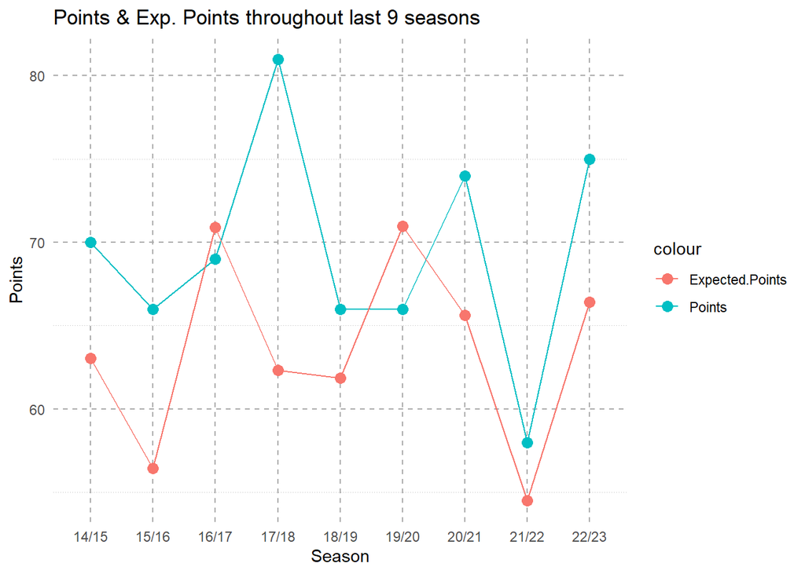

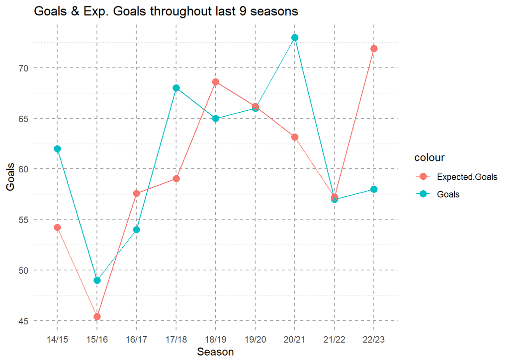

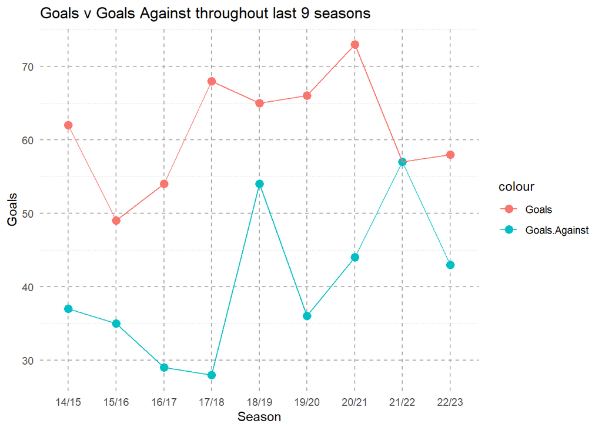

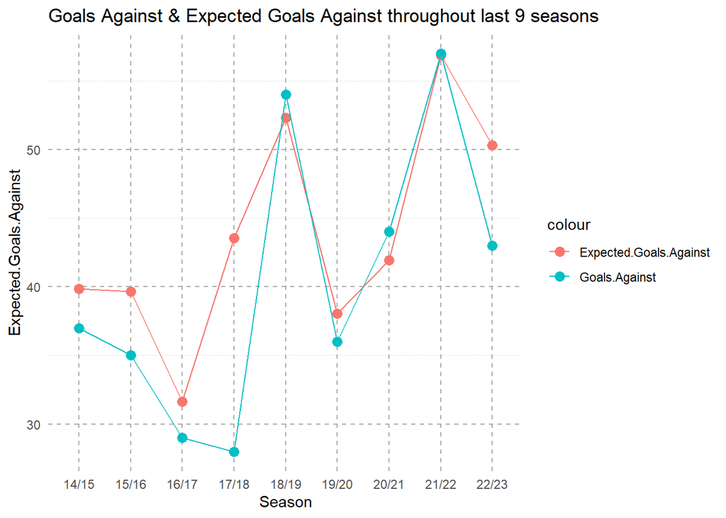

## Mean of Points

```
## [1] 69.44444
```

## Mean of Expected Points

```
## [1] 63.56667
```

Although the mean is close for Points and Expected Points, how much confident are we that there is an over-performance

Doing the bootstrap re-sampling to find difference between points, expected points and see the confidence intervals. Checks if they overlap or not, if they do not, then it shows considerable over-performance. If not, then the over-performance is not statistically significant.

# Declaring Simulation Samples

```r
B <- 1000
N <- 5000
```

# Bootstrap Sampling for Expected Points and Points

### Correlation between the data

```
## [1] 0.004267425
```

### Histogram of Samples Generated

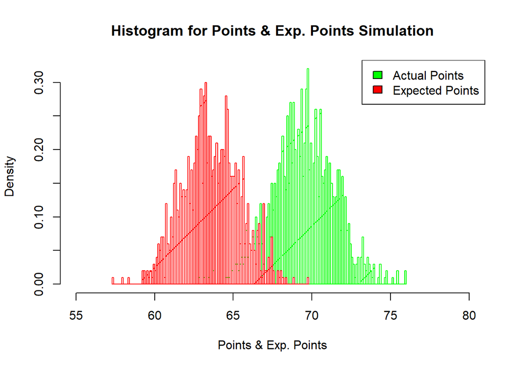

### Boxplot of Points and Exp. Points

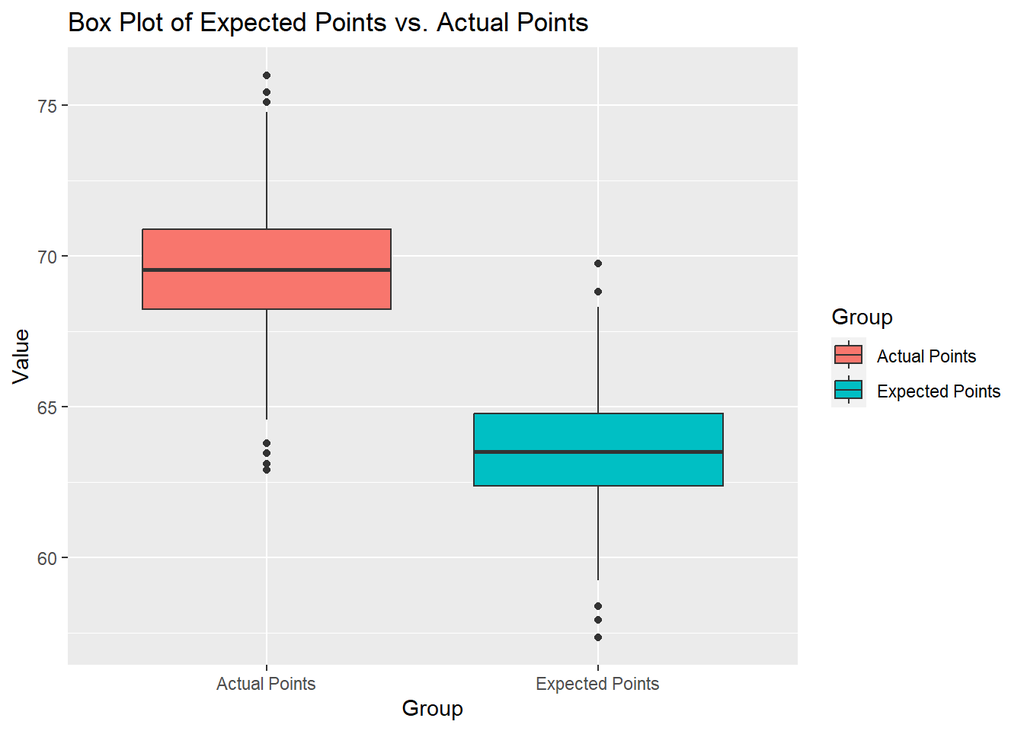

### Standard Normal Confidence Interval

```r
norm_ci_func <- function(x){
  z <- qnorm(.975)

  norm_mean <- mean(x)
  norm_sd <- sd(x)
  norm_ci <- norm_mean + c(-1 , 1) * z * norm_sd

  return(norm_ci)
}
```

### Basic Bootstrap Confidence Interval

```r
basic_boot_ci_func <- function(x,y){
  basic_boot_ci <- 2 * mean(x) - quantile(y, c(0.975, 0.025))
}
```

### Percentile Bootstrap Confidence Interval

```r
percent_ci_func <- function(x){
  return(quantile(x, c(0.025, 0.975)))
}
```

### BCa Bootstrap Confidence Intervals

```r
bca_boot_ci_func <- function(x,y){

theta_hat <- mean(x)
p <- mean(y < theta_hat)
z0_hat <- qnorm(p)

point_jack <- sapply(1:n, function(i) mean(x[-i]))
a_hat <- sum((mean(point_jack) - point_jack) ^3) / (6 * sum((point_jack - mean(point_jack))^2) ^(3/2))

z <- qnorm(c(0.025, 0.975))

alpha <- pnorm(z0_hat + (z0_hat+z)/(1-a_hat*(z0_hat+z)))

bca_ci_points <- quantile(y, alpha)

return(bca_ci_points)

}
```

# Monte Carlo Simulation and Bootstrapping

### Standard Normal CI

```r
n_list <- list(5, 7, 9)

for(lst in n_list){
for(rep in 1:N){ # Monte Carlo Simulation

  # Bootstrap Sampling
  points_boot <- replicate(B, data_points[sample.int(lst, lst, replace = TRUE)])
  exp_points_boot <- replicate(B, data_exp_points[sample.int(lst, lst, replace = TRUE)])

  data_points_mean <- apply(points_boot, 2, mean)
  data_exp_points_mean <- apply(exp_points_boot, 2, mean)

  # Mean of Samples
  mean_points_boot <- mean(data_points_mean) # Mean of Bootstrap Sample Points
  mean_exp_points_boot <- mean(data_exp_points_mean)

  # Standard Normal CI
  norm_ci_points <- apply(points_boot, 1, norm_ci_func) # Points
  norm_ci_exp_points <- apply(exp_points_boot, 1, norm_ci_func) #norm_ci_func(data_exp_points_mean) # Exp Points

  # Cov Prob and Width for Points
  coverage_probability <- mean(points_mu >= norm_ci_points[1] & points_mu <= norm_ci_points[2])
  average_width <- norm_ci_points[2] - norm_ci_points[1]

  # Cov Prob and Width for Exp. Points
  exp_coverage_probability <- mean(exp_points_mu >= norm_ci_exp_points[1] & points_mu <= norm_ci_exp_points[2])
  exp_average_width <- norm_ci_exp_points[2] - norm_ci_exp_points[1]

}

cov_se <- sqrt(mean(coverage_probability) * (1 - mean(coverage_probability))/N)
cov_exp_se <- sqrt(mean(exp_coverage_probability) * (1 - mean(exp_coverage_probability))/N)

Temp_Points_df <- data.frame(Method = 'Standard Normal',
                             Column = 'Points', n = lst,
                             mean = mean_points_boot,
                          Coverage_Prob = mean(coverage_probability),
                          LCL = norm_ci_points[1],
                          UCL = norm_ci_points[2],
                          CovLCL = mean(coverage_probability) - 2 * cov_se,
                          CovUCL = mean(coverage_probability) + 2 * cov_se,
                          Width = mean(average_width))
Points_df  <- bind_rows(Points_df , Temp_Points_df)

Temp_Points_df <- data.frame(Method = 'Standard Normal',
                             Column = 'Exp. Points', n = lst,
                             mean = mean_exp_points_boot,
                          Coverage_Prob = mean(exp_coverage_probability),
                          LCL = norm_ci_exp_points[1],
                          UCL = norm_ci_exp_points[2],
                          CovLCL = mean(exp_coverage_probability) - 2 * cov_exp_se,
                          CovUCL = mean(exp_coverage_probability) + 2 * cov_exp_se,
                          Width = mean(exp_average_width))
Points_df  <- bind_rows(Points_df , Temp_Points_df)

}
```

### Created DataFrame

|  | Method | Column | n | mean | Coverage_Prob | LCL | UCL | CovLCL | CovUCL | Width |
| --- | --- | --- | --- | --- | --- | --- | --- | --- | --- | --- |
| ...1 | Standard Normal | Points | 5 | 70.38260 | 1 | 59.54540 | 81.46660 | 1 | 1 | 21.92121 |
| ...2 | Standard Normal | Exp. Points | 5 | 62.83689 | 1 | 53.99315 | 71.61925 | 1 | 1 | 17.62610 |
| ...3 | Standard Normal | Points | 7 | 70.28100 | 1 | 60.27899 | 80.39301 | 1 | 1 | 20.11402 |
| ...4 | Standard Normal | Exp. Points | 7 | 64.39456 | 1 | 54.79708 | 73.96984 | 1 | 1 | 19.17277 |
| ...5 | Standard Normal | Points | 9 | 69.33022 | 1 | 56.67613 | 81.93187 | 1 | 1 | 25.25574 |
| ...6 | Standard Normal | Exp. Points | 9 | 63.62238 | 1 | 53.01334 | 74.07780 | 1 | 1 | 21.06445 |
| 97.5%...7 | Basic Bootstrap | Points | 5 | 70.44740 | 1 | 57.88889 | 72.88889 | 1 | 1 | 15.00000 |
| 97.5%...8 | Basic Bootstrap | Exp. Points | 5 | 62.86490 | 1 | 56.24333 | 70.69333 | 1 | 1 | 14.45000 |
| 97.5%...9 | Basic Bootstrap | Points | 7 | 70.26171 | 1 | 57.88889 | 72.88889 | 1 | 1 | 15.00000 |
| 97.5%...10 | Basic Bootstrap | Exp. Points | 7 | 64.43234 | 1 | 56.14333 | 70.69333 | 1 | 1 | 14.55000 |

[output cut: 14 more lines]

### Plotting

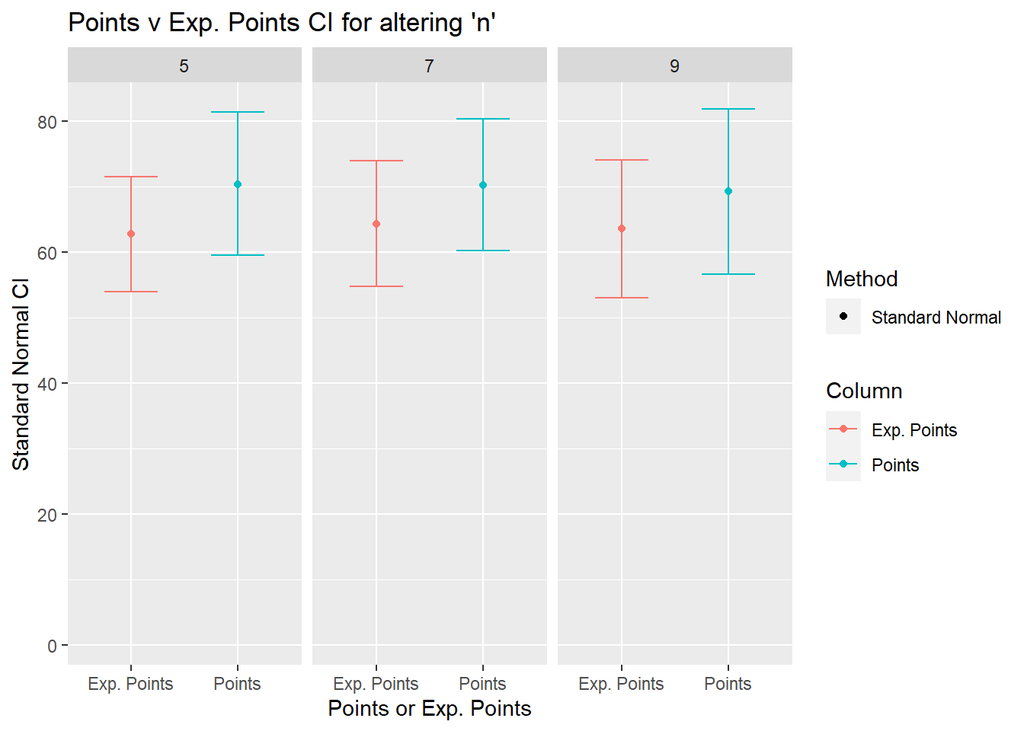

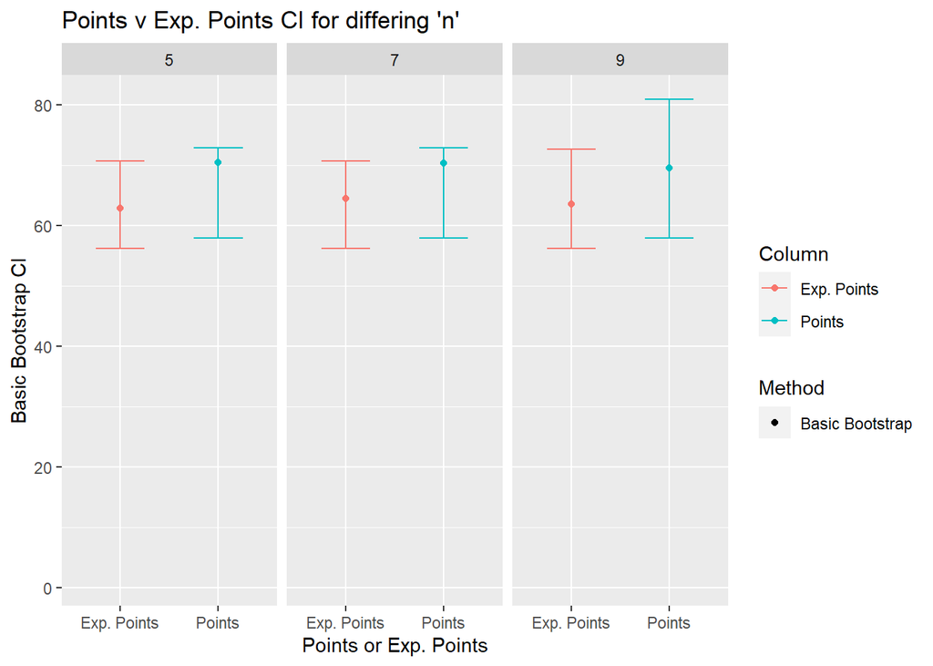

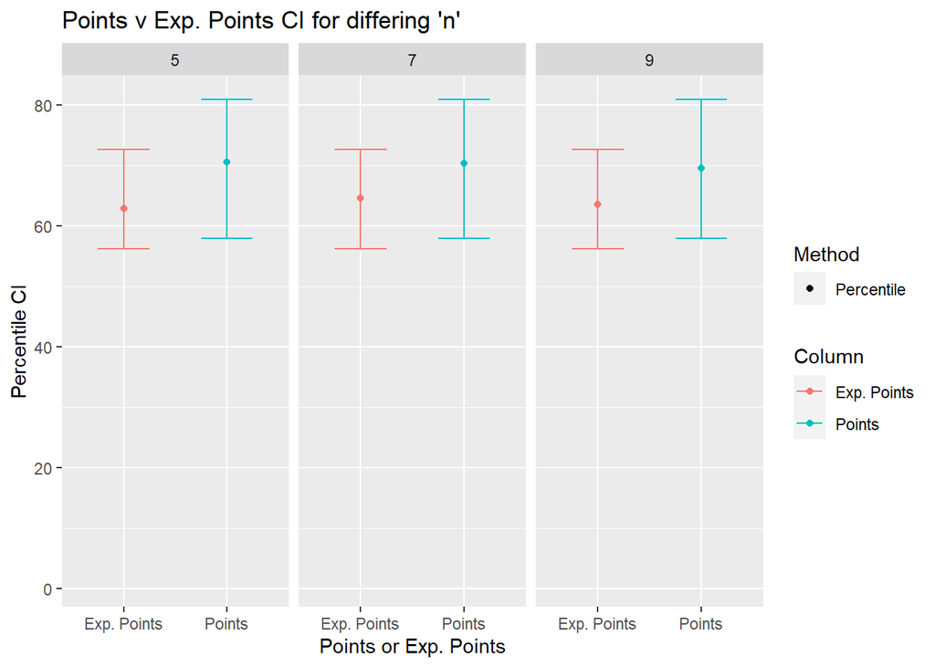

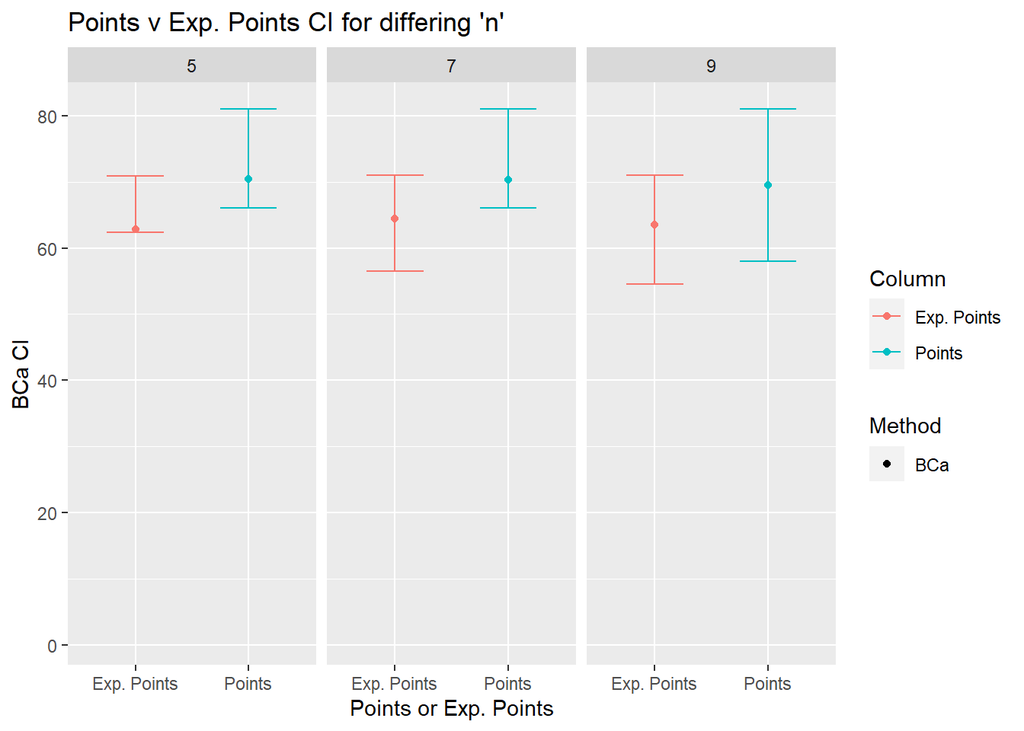

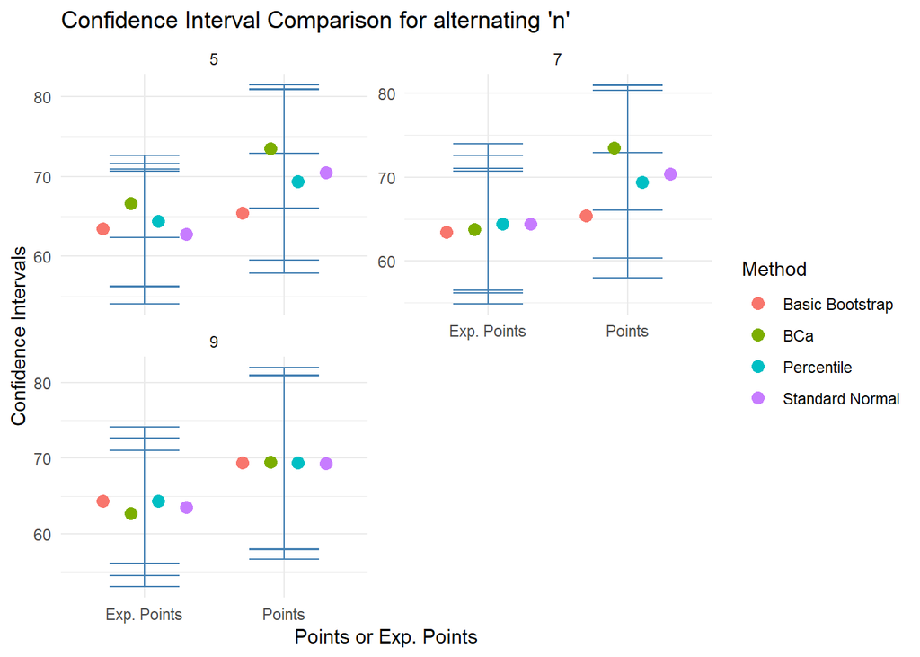